# NLP+K-Means

### NLP自然語言處理

#### Jieba 中文斷字詞

- **規則斷詞**  
  主要是透過詞典，在對句子進行斷詞的時候，將句子的每個字與詞典中的詞進行匹配，找到則斷詞，否則無法斷詞。
- **統計斷詞**  
  主要是看如果相連的字在不同的文本中出現的次數越多，就推斷這相連的字很可能就是一個詞。因此就可以利用字與字相鄰出现的頻率來做統計。當高於某一個臨界值時，便可認為此字組是一個詞語。

#### 精確模式 (預設模式)

將句子最精確的切開，適合文本分析

#### 全模式

把句子中所有的可以成詞的詞語都斷出来，速度快

#### 搜索引擎模式

精確模式的基礎上，對長的詞語再次切分，提高召回率，適合用於搜索引擎分詞

#### 支援自定義詞典

```python
import jieba

sentenceA = '今天星期六,我來到花蓮慈濟科技大學參加課程活動!'
sentenceB = '今天星期六,我来到花莲慈济科技大学参加课程活动!'

# 精確模式
seg_listA = jieba.cut(sentenceA) #  .lcut() return list
print("預設模式 (繁體): " + " | ".join(seg_listA))
seg_listB = jieba.cut(sentenceB)
print("預設模式 (簡體): " + " | ".join(seg_listB))

# 全模式
seg_listA = jieba.cut(sentenceA, cut_all=True)
print("全模式: " + " | ".join(seg_listA))
seg_listB = jieba.cut(sentenceB, cut_all=True)
print("全模式: " + " | ".join(seg_listB))

# 搜尋引擎模式
seg_listA = jieba.cut_for_search(sentenceA)
print("搜尋引擎模式 (繁體): " + "| ".join(seg_listA))
seg_listB = jieba.cut_for_search(sentenceB)
print("搜尋引擎模式 (簡體): " + "| ".join(seg_listB))
```

```
Building prefix dict from the default dictionary ...
Dumping model to file cache C:\Users\NickLin\AppData\Local\Temp\jieba.cache
Loading model cost 2.328 seconds.
Prefix dict has been built successfully.
```

```
預設模式 (繁體): 今天 | 星期六 | , | 我來 | 到 | 花蓮 | 慈濟 | 科技 | 大學 | 參加 | 課程 | 活動 | !
預設模式 (簡體): 今天 | 星期六 | , | 我 | 来到 | 花莲 | 慈济 | 科技 | 大学 | 参加 | 课程 | 活动 | !
全模式: 今天 | 天星 | 星期 | 星期六 | , | 我 | 來 | 到 | 花 | 蓮 | 慈 | 濟 | 科技 | 大 | 學 | 參 | 加 | 課 | 程 | 活 | 動 | !
全模式: 今天 | 天星 | 星期 | 星期六 | , | 我 | 来到 | 花莲 | 慈济 | 济科 | 科技 | 大学 | 参加 | 加课 | 课程 | 活动 | !
搜尋引擎模式 (繁體): 今天| 星期| 星期六| ,| 我來| 到| 花蓮| 慈濟| 科技| 大學| 參加| 課程| 活動| !
搜尋引擎模式 (簡體): 今天| 星期| 星期六| ,| 我| 来到| 花莲| 慈济| 科技| 大学| 参加| 课程| 活动| !
```

```python
# join 用法
a = ['a','b','c','d']
b = '%'.join(a)
b
```

```
'a%b%c%d'
```

#### 自訂辭典

```python
sentence = '行政院推出「振興三倍券」刺激消費，實體券可從郵局購買。政務委員唐鳳今天說，屆時會有類似口罩地圖的介面，讓民眾知道哪裡的郵局還有存量，也就是「三倍券地圖'
seg_list = jieba.cut(sentence)
print(" | ".join(seg_list))
```

```
行政院 | 推出 | 「 | 振興 | 三倍 | 券 | 」 | 刺激 | 消費 | ， | 實體券 | 可 | 從 | 郵局 | 購買 | 。 | 政務委員 | 唐鳳 | 今天 | 說 | ， | 屆 | 時會 | 有 | 類似 | 口罩 | 地圖 | 的 | 介面 | ， | 讓民眾 | 知道 | 哪裡 | 的 | 郵局 | 還有 | 存量 | ， | 也 | 就是 | 「 | 三倍 | 券地 | 圖
```

```python
jieba.load_userdict('data/user_dict.txt')
```

[output not shown]

```python
seg_list = jieba.cut(sentence)
print(" | ".join(seg_list))
```

[output not shown]

#### 調整詞典

- 預設詞庫 : https://raw.githubusercontent.com/fxsjy/jieba/master/jieba/dict.txt
- add_word(word, freq=None, tag=None)
- del_word(word)
- suggest_freq(segment, tune=True)

```python
sentence ='中央流行疫情指揮中心宣布，台灣今天沒有新增新冠肺炎（2019冠狀病毒疾病，COVID-19）確診，連續52天沒有本土個案，全台累計443例，428人解除隔離。'
print('/'.join(jieba.cut(sentence)))
```

```
中央/流行/疫情/指揮/中心/宣布/，/台灣/今天/沒有/新增/新冠/肺炎/（/2019/冠狀/病毒/疾病/，/COVID/-/19/）/確診/，/連續/52/天沒有/本土/個案/，/全台/累計/443/例/，/428/人/解除/隔離/。
```

```python
jieba.add_word('2019冠狀病毒疾病', freq=None, tag=None)
jieba.add_word('COVID-19', freq=None, tag=None)
jieba.suggest_freq(('天','沒有'), tune=True)
```

```
0
```

```python
sentence ='中央流行疫情指揮中心宣布，台灣今天沒有新增新冠肺炎（2019冠狀病毒疾病，COVID-19）確診，連續52天沒有本土個案，全台累計443例，428人解除隔離。'
print('/'.join(jieba.cut(sentence)))
```

```
中央/流行/疫情/指揮/中心/宣布/，/台灣/今天/沒有/新增/新冠/肺炎/（/2019冠狀病毒疾病/，/COVID-19/）/確診/，/連續/52/天/沒/有/本土/個案/，/全台/累計/443/例/，/428/人/解除/隔離/。
```

#### Tokenize：返回詞語在原文的起止位置

```python
sentence =u'中央流行疫情指揮中心宣布，台灣今天沒有新增新冠肺炎（2019冠狀病毒疾病，COVID-19）確診，連續52天沒有本土個案，全台累計443例，428人解除隔離。'
result = jieba.tokenize(sentence)
#result = jieba.tokenize(sentence,mode='search') # 搜尋模式

for tk in result:
    print("word %s\t\t start: %d \t\t end:%d" % (tk[0],tk[1],tk[2]))
```

```
word 中央		 start: 0 		 end:2
word 流行		 start: 2 		 end:4
word 疫情		 start: 4 		 end:6
word 指揮		 start: 6 		 end:8
word 中心		 start: 8 		 end:10
word 宣布		 start: 10 		 end:12
word ，		 start: 12 		 end:13
word 台灣		 start: 13 		 end:15
word 今天		 start: 15 		 end:17
word 沒有		 start: 17 		 end:19
word 新增		 start: 19 		 end:21
word 新冠		 start: 21 		 end:23
word 肺炎		 start: 23 		 end:25
word （		 start: 25 		 end:26
word 2019冠狀病毒疾病		 start: 26 		 end:36
word ，		 start: 36 		 end:37
word COVID-19		 start: 37 		 end:45
word ）		 start: 45 		 end:46
word 確診		 start: 46 		 end:48
word ，		 start: 48 		 end:49
word 連續		 start: 49 		 end:51
word 52		 start: 51 		 end:53
word 天		 start: 53 		 end:54
word 沒		 start: 54 		 end:55
word 有		 start: 55 		 end:56
word 本土		 start: 56 		 end:58
word 個案		 start: 58 		 end:60
word ，		 start: 60 		 end:61
word 全台		 start: 61 		 end:63
word 累計		 start: 63 		 end:65
word 443		 start: 65 		 end:68
word 例		 start: 68 		 end:69
word ，		 start: 69 		 end:70
word 428		 start: 70 		 end:73
word 人		 start: 73 		 end:74
word 解除		 start: 74 		 end:76
word 隔離		 start: 76 		 end:78
word 。		 start: 78 		 end:79
```

#### 詞性標註

- 北大計算所詞性標註集

http://ictclas.nlpir.org/nlpir/html/readme.htm

```python
import jieba.posseg as pseg

sentence ='中央流行疫情指揮中心宣布，台灣今天沒有新增新冠肺炎（2019冠狀病毒疾病，COVID-19）確診，連續52天沒有本土個案，全台累計443例，428人解除隔離。'
words = pseg.cut(sentence)

for word, flag in words:
     print('%s %s' % (word, flag))
```

```
中央 n
流行 v
疫情 n
指揮 v
中心 n
宣布 v
， x
台灣 ns
今天 t
沒有 v
新增 v
新冠 n
肺炎 n
（ x
2019冠狀病毒疾病 x
， x
COVID eng
- x
19 m
） x
確診 v
， x
連續 a
52 m
天 q
沒有 v
本土 n
個案 n
， x
全台 n
累計 v
443 m
例 v
， x
428 m
人 n
解除 v
隔離 v
。 x
```

#### 關鍵字提取

- 基於 TF-IDF 演算法的關鍵詞抽取

  jieba.analyse.extract_tags(sentence, topK=20, withWeight=False, allowPOS=())

```python
import jieba.analyse

tags = jieba.analyse.extract_tags(sentence)

print(",".join(tags))
```

```
指揮,台灣,沒有,新冠,2019冠狀病毒疾病,COVID-19,確診,連續,52,個案,累計,443,428,隔離,全台,肺炎,疫情,本土,解除,流行
```

- 基於 TextRank 演算法的關鍵詞抽取

  jieba.analyse.textrank(sentence, topK=20, withWeight=False, allowPOS=('ns', 'n', 'vn', 'v'))

```python
tags = jieba.analyse.textrank(sentence)

keywords = ",".join(tags)
print(keywords)
```

```
沒有,台灣,宣布,指揮,中心,隔離,解除,疫情,流行,本土,全台,個案,新增,新冠,中央,累計,肺炎
```

#### 文字雲

```python
import matplotlib.pyplot as plt
import numpy
from collections import Counter
from wordcloud import WordCloud
from PIL import Image
```

```python
diction = Counter(tags)
print(diction)
```

```
Counter({'沒有': 1, '台灣': 1, '宣布': 1, '指揮': 1, '中心': 1, '隔離': 1, '解除': 1, '疫情': 1, '流行': 1, '本土': 1, '全台': 1, '個案': 1, '新增': 1, '新冠': 1, '中央': 1, '累計': 1, '肺炎': 1})
```

```python
font = "C:\\Windows\\Fonts\\simsun.ttc"
cloud =WordCloud(background_color="white",font_path=font)
cloud.generate_from_frequencies(diction)
```

```
<wordcloud.wordcloud.WordCloud at 0x1d96c2d3548>
```

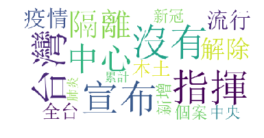

```python
plt.figure(figsize=(6,6))
plt.imshow(cloud)
plt.axis("off")
plt.show()
```

### K-MEANS 文本分群

安裝套件

- pip3 install xlrd
- pip3 install jieba

```python
import pandas
newsdf = pandas.read_excel('data/newslist.xlsx')
```

```python
newsdf.head()
```

|  | title | summary |
| --- | --- | --- |
| 0 | 菊勸退賴 新系立委卻這麼想…賴出線 有利立委選舉 | 行政院前院長賴清德角逐民進黨總統初選，賴清德所屬新潮流系前天開會因應，總統府秘書長陳菊也與會... |
| 1 | 健保砍價外資藥廠爆退藥潮 製藥公會：本土藥廠可供應 | 繼百憂解之後，20日再傳治療革蘭氏陰性菌的最後一線用藥泰寧，亦將退出台灣市場；製藥同業公會蘇... |
| 2 | 口罩銷售解禁！ 各大商店開賣日期價格一次看 | 為防堵新冠肺炎（2019冠狀病毒疾病，COVID-19）疫情擴散，政府今年1月啟動口罩徵收制... |
| 3 | 波音737 MAX機瘟 美媒：FBI介入刑事調查 | 美國「西雅圖時報」（The Seattle Times）20日引述知情人士報導，美國聯邦調查... |
| 4 | 周玉蔻罵警像流氓和解 判拘役30天緩刑2年定讞 | 媒體人周玉蔻在政論節目指一名來賓（員警）說話「像流氓」，一審法院判周玉蔻拘役50天得易科罰金... |

```python
import jieba

title_ary = []
article_ary = []

for news in newsdf.iterrows():
    print(news[1])
    article_ary.append(' '.join(jieba.cut(news[1].summary)))
    title_ary.append(news[1].title)
```

```
title                               菊勸退賴 新系立委卻這麼想…賴出線 有利立委選舉
summary    行政院前院長賴清德角逐民進黨總統初選，賴清德所屬新潮流系前天開會因應，總統府秘書長陳菊也與會...
Name: 0, dtype: object
title                              健保砍價外資藥廠爆退藥潮 製藥公會：本土藥廠可供應
summary    繼百憂解之後，20日再傳治療革蘭氏陰性菌的最後一線用藥泰寧，亦將退出台灣市場；製藥同業公會蘇...
Name: 1, dtype: object
title                                  口罩銷售解禁！ 各大商店開賣日期價格一次看
summary    為防堵新冠肺炎（2019冠狀病毒疾病，COVID-19）疫情擴散，政府今年1月啟動口罩徵收制...
Name: 2, dtype: object
title                               波音737 MAX機瘟 美媒：FBI介入刑事調查
summary    美國「西雅圖時報」（The Seattle Times）20日引述知情人士報導，美國聯邦調查...
Name: 3, dtype: object
title                                周玉蔻罵警像流氓和解 判拘役30天緩刑2年定讞
summary    媒體人周玉蔻在政論節目指一名來賓（員警）說話「像流氓」，一審法院判周玉蔻拘役50天得易科罰金...
Name: 4, dtype: object
title                             南山片面更改收費方式造成保戶權益受損 金管會4月開罰
summary    南山人壽大砍收費員，在未經客戶同意之下片面變更保費收費方式，造成200多件保單停效、2000...
Name: 5, dtype: object
title                                  緬甸華僑入境情緒失控 攻擊檢疫犬打傷領犬員
summary    防堵非洲豬瘟疫情，機場的檢疫犬發揮了很大的功能，但是昨(19)日卻發生了一起入境旅客攻擊檢疫...
Name: 6, dtype: object
title                                      賴清德：若當台灣總統 拚經濟最重要
summary    行政院前院長賴清德周一登記參與民進黨總統初選，總統蔡英文預定今天赴民進黨登記初選，旋即出國拚...
Name: 7, dtype: object
title                            台中空品差！他貼盧秀燕轟中央遭網噓　引林佳龍留言網狂讚
summary    近日來中南部空品不佳，空汙嚴重，台中市長盧秀燕18日再度向中央開砲表示，「空汙最嚴重的地方降...
Name: 8, dtype: object
title                                  不滿檢疫犬嗅行李 旅客用推車撞狗打人遭送辦
summary    一名緬甸籍華僑昨天入境台灣時，疑因不滿檢疫犬嗅聞其行李，情緒一時失控涉以推車推撞檢疫犬，並拍...
Name: 9, dtype: object
title                                     非裔之死全美示威 拜登現身德拉瓦現場
summary    在稍早前，拜登也曾發表聲明，譴責種族暴力，表示美國人民有示威的權利，但他也譴責示威過程中的暴...
Name: 10, dtype: object
title                         波音737 MAX 8失事黑盒子曝光　與獅航空難「非常相似」
summary    衣索比亞政府16日表示，根據出事飛機波音737 MAX 8客機上的「黑盒子」數據，顯示出這一...
Name: 11, dtype: object
title                                 罵退休警「流氓、黑道」 周玉蔻賠15萬獲緩刑
summary    媒體人周玉蔻在政論節目指一名來賓（員警）說話「像流氓」，一審法院判周玉蔻拘役50天得易科罰金...
Name: 12, dtype: object
title                                      健保砍藥價，傷的是台廠、不是原廠！
```

[output cut: 29 more lines]

```
title                                   罷韓投票防疫 須量體溫戴口罩保持社交距離
summary    高雄市6月6日要舉辦罷免市長韓國瑜投票，高雄市選委會今天說明並要求投票民眾須配合戴口罩、量測...
Name: 23, dtype: object
title                                     口罩解禁哪裡買一次看　小七今開放預購
summary    口罩禁令於今（1日）解除，口罩不僅可以外銷，也能在國內販售。疫情指揮中心指揮官陳時中表示，預...
Name: 24, dtype: object
title                           非裔男之死∕美國爆抗議近1400人被捕 德州進入災難狀態
summary    美國非裔男子佛洛伊德遭警員壓頸致死，引發全美各地示威抗議，有些地方轉為暴力事件，估計全美有近...
Name: 25, dtype: object
title                                 全美抗議失序暴亂 華府實施宵禁動員國民兵支援
summary    非裔美國男子佛洛伊德（George Floyd）日前遭白人警察壓頸致死，在全美引發暴力示威，...
Name: 26, dtype: object
title                                  新增1例境外移入 50多歲女美國出差遭感染
summary    中央流行疫情指揮中心今（1）日公布國內新增1例武漢肺炎（亦稱新冠肺炎，COVID-19）確診...
Name: 27, dtype: object
```

```python
from sklearn.feature_extraction.text import CountVectorizer  # feature_extraction.text 文本特徵提取
vectorizer = CountVectorizer() #詞語轉換成詞頻矩陣
X = vectorizer.fit_transform(article_ary) #計算各詞語出現次數
```

```python
print(X)  # (文本序號,詞序號) 詞頻
```

```
  (0, 1731)	1
  (0, 475)	1
  (0, 1839)	7
  (0, 1761)	1
  (0, 1294)	5
  (0, 1604)	3
  (0, 458)	1
  (0, 963)	1
  (0, 1086)	1
  (0, 470)	1
  (0, 2022)	2
  (0, 647)	1
  (0, 1605)	1
  (0, 1519)	1
  (0, 228)	1
  (0, 722)	3
  (0, 1141)	1
  (0, 1168)	1
  (0, 2152)	1
  (0, 184)	1
  (0, 455)	1
  (0, 1158)	2
  (0, 1029)	2
  (0, 379)	2
  (0, 187)	1
  :	:
  (27, 451)	1
  (27, 389)	1
  (27, 300)	1
  (27, 1663)	1
  (27, 1947)	1
  (27, 944)	1
  (27, 1345)	1
  (27, 249)	1
  (27, 1886)	1
  (27, 1700)	1
  (27, 9)	1
  (27, 447)	1
  (27, 189)	1
  (27, 1001)	1
  (27, 830)	1
  (27, 456)	1
  (27, 724)	1
  (27, 1997)	1
  (27, 1803)	1
  (27, 1097)	1
  (27, 1651)	1
  (27, 573)	1
  (27, 100)	1
  (27, 279)	1
  (27, 1778)	1
```

```python
feature_name = vectorizer.get_feature_names()
feature_name
```

```
['10',
 '100',
 '106',
 '11',
 '12',
 '120',
 '13',
 '130',
 '132',
 '14',
 '1400',
 '15',
 '157',
 '16',
 '18',
 '19',
 '20',
 '200',
 '2000',
 '2014',
 '2015',
 '2017',
 '2019冠狀病毒疾病',
 '2020',
 '2025',
 '21',
 '22',
 '237',
 '25',
 '250',
 '2861',
 '287',
 '29',
 '299',
 '30',
 '300',
 '3039',
 '31',
 '319',
 '352',
```

[output cut: 946 more lines]

```
 '抗議民眾',
 '抵達',
 '拆除',
 '拍打',
 '拘役',
 '拚經濟',
 '拜登',
 '拿下',
 '拿到',
 '持有',
 '持續',
 '指出',
 '指引',
 '指控',
 ...]
```

```python
X.toarray()
```

```
array([[0, 0, 0, ..., 0, 0, 0],
       [0, 0, 0, ..., 0, 0, 0],
       [0, 0, 0, ..., 0, 0, 0],
       ...,
       [0, 0, 0, ..., 0, 0, 0],
       [0, 0, 0, ..., 0, 0, 0],
       [0, 0, 0, ..., 0, 1, 0]], dtype=int64)
```

```python
from sklearn.metrics.pairwise import cosine_similarity
cosine_similarities = cosine_similarity(X,X)
```

```python
from sklearn.cluster import KMeans
kmeans = KMeans(n_clusters = 8, init = 'k-means++', random_state = 123)
#kmeans = KMeans(n_clusters = 8)
y_kmeans = kmeans.fit_predict(cosine_similarities)
```

```python
import numpy
from collections import Counter
title_npary = numpy.array(title_ary)
Counter(y_kmeans)

y_kmeans
```

```
array([3, 3, 5, 0, 1, 3, 2, 3, 3, 2, 6, 0, 1, 3, 2, 1, 3, 0, 4, 4, 7, 7,
       7, 7, 5, 6, 6, 5])
```

```python
for i in range(0,8):
    print("cluste -",i)
    print("-----------------")
    for ele in title_npary[y_kmeans == i]:
        print(i," ",ele)
    print("-----------------")
```

```
cluste - 0
-----------------
0   波音737 MAX機瘟 美媒：FBI介入刑事調查
0   波音737 MAX 8失事黑盒子曝光　與獅航空難「非常相似」
0   美媒揭露：駕駛波音737 MAX　只要上1小時iPad課程
-----------------
cluste - 1
-----------------
1   周玉蔻罵警像流氓和解 判拘役30天緩刑2年定讞
1   罵退休警「流氓、黑道」 周玉蔻賠15萬獲緩刑
1   上節目罵警察 蔻蔻姊賠15萬獲緩刑
-----------------
cluste - 2
-----------------
2   緬甸華僑入境情緒失控 攻擊檢疫犬打傷領犬員
2   不滿檢疫犬嗅行李 旅客用推車撞狗打人遭送辦
2   「護國神犬」遭施暴 緬甸華僑推車撞檢疫犬
-----------------
cluste - 3
-----------------
3   菊勸退賴 新系立委卻這麼想…賴出線 有利立委選舉
3   健保砍價外資藥廠爆退藥潮 製藥公會：本土藥廠可供應
3   南山片面更改收費方式造成保戶權益受損 金管會4月開罰
3   賴清德：若當台灣總統 拚經濟最重要
3   台中空品差！他貼盧秀燕轟中央遭網噓　引林佳龍留言網狂讚
3   健保砍藥價，傷的是台廠、不是原廠！
3   空汙Bang不見？檢舉空汙App疑下架　台中市府闢謠
-----------------
cluste - 4
-----------------
4   空服工會反對設立罷工預告期 林佳龍今晚找勞團協商
4   長榮罷工醞釀中 空服工會籲林佳龍撤罷工預告制度
-----------------
cluste - 5
-----------------
5   口罩銷售解禁！ 各大商店開賣日期價格一次看
5   口罩解禁哪裡買一次看　小七今開放預購
5   新增1例境外移入 50多歲女美國出差遭感染
-----------------
cluste - 6
-----------------
6   非裔之死全美示威 拜登現身德拉瓦現場
6   非裔男之死∕美國爆抗議近1400人被捕 德州進入災難狀態
6   全美抗議失序暴亂 華府實施宵禁動員國民兵支援
-----------------
cluste - 7
-----------------
7   全力挺韓 藍委：即使被罷免也要做到最後一天
7   罷韓連5天遊行 綠民代街頭催票
7   韓陣營定調「五不做」 韓國瑜不會對罷免結果公開談話
7   罷韓投票防疫 須量體溫戴口罩保持社交距離
-----------------
```